# Validation of rGFA functions

Hung-Wen Yeh

1/8/2020

# 0. Setup

```r
rm(list=ls())
mydir <- "/Users/hyeh/Dropbox (LIBR)/Henry_Yeh/GFA/rGFA_simu/" # setwd(mydir)
```

## 0.1 Required packages

```r
# library(caret)
library(GFA)
opts <- getDefaultOpts()
opts$convergenceCheck <- T
# library(doParallel); cl = 10; registerDoParallel(cores=cl)
library(knitr)
library(gplots)
library(ggplot2)
```

## 0.2 Supporting functions

```r
source(paste0(mydir, "R_scripts/rGFA_simu_fcn.R"))
```

```r
varIdx.by.block <- list(c(1:15), c(16:25), c(26:30), c(31:40))
corGrids <- matchGrids <- c(seq(0.1, 0.5, by=0.2), seq(0.6, 0.9, 0.1))
block.names = paste0("Block_", 1:4)
block4vars <- c(rep("Block_1", length(varIdx.by.block[[1]])),
                rep("Block_2", length(varIdx.by.block[[2]])),
                rep("Block_3", length(varIdx.by.block[[3]])),
                rep("Block_4", length(varIdx.by.block[[4]])))
```

# 1. (N,D,K,sd.noise) = (100, 40, 7, 0)

## 1.1. Simulate data

W matrix:

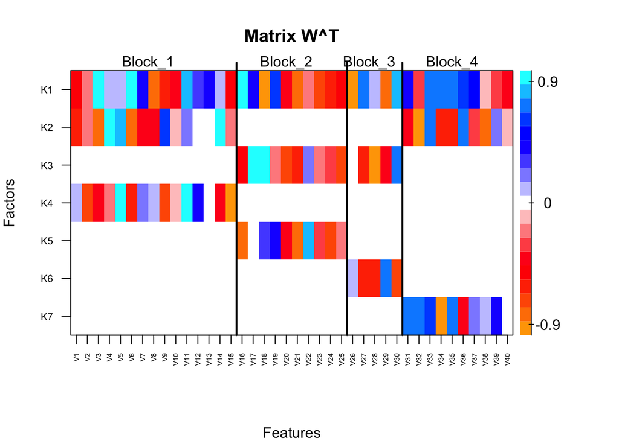

```r
# block.names <- paste0("Block_", 1:4)
set.seed(123)
W <- matrix(tanh(rnorm(7*40)), 40, 7)
colnames(W) <- paste0("K", 1:ncol(W))
rownames(W) <- paste0("V", 1:nrow(W))
W[c(varIdx.by.block[[2]], varIdx.by.block[[3]]), 2] <-
  W[c(varIdx.by.block[[1]], varIdx.by.block[[4]]), 3] <- 0
W[c(varIdx.by.block[[2]], varIdx.by.block[[3]], varIdx.by.block[[4]]), 4] <-
  W[c(varIdx.by.block[[1]], varIdx.by.block[[3]], varIdx.by.block[[4]]), 5] <-
  W[c(varIdx.by.block[[1]], varIdx.by.block[[2]], varIdx.by.block[[4]]), 6] <-
  W[c(varIdx.by.block[[1]], varIdx.by.block[[2]], varIdx.by.block[[3]]), 7] <- 0
# round(tmp, 1)
W_heatmap(W_DxK=W, varIdx.by.block, block.names)
```

X and Y

```r
folder <- "N100_D40_K7_noise0"
set.seed(123)
dat <- data.simu(N=100, W_DxK=W, varIdx.by.block, sd.noise=0)
names(dat$Y.list) <- block.names
mynorm <- normalizeData(train=dat$Y.list, type="scaleFeatures")
Y <- do.call(cbind, mynorm$train)
```

```r
veTrue <- rep(NA)
for(k in 1:7){
  veTrue[k] <- mean(diag(as.matrix(W[, k]) %*% as.matrix(t(W[, k])))) * diag(var(dat$X))[k]
}
round(veTrue, 2); sum(veTrue)
apply(W^2, 2, mean)
sum(apply(W^2, 2, mean))
round(apply(dat$X, 2, sd), 2)
```

## 1.2 Replicate GFA

```r
# sapply(mynorm$train, dim); table(unlist(sapply(mynorm$train, function(x) round(apply(x, 2, mean), 1)))); table(unlist(sapply(mynorm$train, function(x) round(apply(x, 2, sd), 1))))
foreach(r = 1:10, .packages=c("GFA")) %dopar% {
  set.seed(r)
  res <- gfa(mynorm$train, opts=opts, K=10)
  save(res, file=paste0(mydir, "res/", folder, "/GFA_rep_", r, ".rda"))
}
```

With no noise, all 10 replicates converged and returned the correct K=7:

```r
R <- 10
rep.summ <- data.frame(Replicate=1:R, conv=rep(NA, R), K=rep(NA, R))
gfaList_full <- list()
for(r in 1:R){
  load(paste0(mydir, "res/", folder, "/GFA_rep_", r, ".rda"))
  gfaList_full[[r]] <- res
  rep.summ$conv[r] <- res$conv
  rep.summ$K[r] <- res$K
}
summary(rep.summ$conv)
```

```
##    Min. 1st Qu.  Median    Mean 3rd Qu.    Max.
## 0.04775 0.05087 0.05262 0.05345 0.05713 0.05950
```

```r
table(rep.summ$K)
```

```
##
##  7
## 10
```

```r
# kable(rep.summ, digits=2)
```

## 1.3 Identify robust factors

Compute replicate- and factor-specific effects

```r
R <- 15
rep.summ <- data.frame(Replicate=1:R, conv=rep(NA, R), K=rep(NA, R))
xw <- list()
for(r in 1:R){
  load(paste0(mydir, "res/", folder, "/GFA_rep_", r, ".rda"))
  xw[[r]] <- pmXW_by_factor(res)
  rep.summ$conv[r] <- res$conv
  rep.summ$K[r] <- res$K
}
rep.use <- sort(rep.summ$conv, index.return=T)
rep.use$ix[1:10]
xw <- xw[rep.use$ix[1:10]]
save(xw, file=paste0(mydir, "res/", folder, "/xw_by_rep_comp.rda"))
```

### 1.3.1 Using a list of original GFA objects

```r
load(paste0(mydir, "res/", folder, "/xw_by_rep_comp.rda"))
tmp <- matrix(rep(NA, length(corGrids)*length(matchGrids)),
              nrow = length(corGrids), ncol = length(matchGrids),
              dimnames = list(corThr=corGrids, matchThr=matchGrids))

match_orig <- list(K.girds = tmp, mse.m = tmp, indices = rep( list(list()), length(corGrids) ))

for(i in 1:length(corGrids)){
  for (j in 1:length(matchGrids)){
    # rcomp <- robustComponents(gfaList_full, corThr=corGrids[i], matchThr=matchGrids[j])
    # save(rcomp, file=paste0(mydir, "res/", folder, "/rComp_corThr", corGrids[i], "_matchThr", matchGrids[j], ".rda"))
    load(paste0(mydir, "res/", folder, "/rComp_corThr", corGrids[i], "_matchThr", matchGrids[j], ".rda"))
    match_orig$K.girds[i,j] <- rcomp$Krobust
    match_orig$indices[[i]][[j]] <- rcomp$indices
    if(rcomp$Krobust>0){
      yhat <- apply(rcomp$effect, 1:2, sum, na.rm=T)
      match_orig$mse.m[i,j] <- mean((yhat - Y)^2)
    }
  }
}
save(match_orig, file=paste0(mydir, "res/", folder, "/match_orig.rda"))
```

Summary of the grid search for thresholding parameter combinations:

```r
load(paste0(mydir, "res/", folder, "/match_orig.rda"))

match_orig$K.girds
```

```
##       matchThr
## corThr 0.1 0.3 0.5 0.6 0.7 0.8 0.9
##    0.1   7   7   7   7   7   7   7
##    0.3   7   7   7   7   7   7   7
##    0.5   9   7   7   7   7   7   7
##    0.6  10   7   7   7   7   7   6
##    0.7  12   7   7   7   7   7   4
##    0.8  13   7   7   7   7   6   3
##    0.9  19   7   7   6   6   4   2
```

```r
round(match_orig$mse.m, 3)
```

```
##       matchThr
## corThr   0.1   0.3   0.5   0.6   0.7   0.8   0.9
##    0.1 0.000 0.000 0.000 0.000 0.000 0.000 0.000
##    0.3 0.000 0.000 0.000 0.000 0.000 0.000 0.000
##    0.5 0.266 0.003 0.003 0.003 0.003 0.003 0.003
##    0.6 0.552 0.005 0.005 0.005 0.005 0.005 0.053
##    0.7 0.885 0.005 0.005 0.005 0.005 0.023 0.366
##    0.8 1.284 0.004 0.004 0.004 0.004 0.176 0.712
##    0.9 7.726 0.002 0.002 0.198 0.192 0.673 0.872
```

```r
paste0("The min. MSE = ", round(min(match_orig$mse.m), 3))
```

```
## [1] "The min. MSE = 0"
```

```r
tmp <- match_orig$K.girds
tmp[match_orig$mse.m > min(match_orig$mse.m)] <- NA
tmp[1:2,]
```

```
##       matchThr
## corThr 0.1 0.3 0.5 0.6 0.7 0.8 0.9
##    0.1   7   7   7   7   7   7   7
##    0.3   7   7   7   7   7   7   7
```

Low corThr values (0.1 and 0.3) perfectly reconstructed the data and led to the true K=7. The matching indices were all the same

```r
all.equal(match_orig$indices[[1]], match_orig$indices[[2]])
```

```
## [1] TRUE
```

The matching indices for the (corThr, matchThr) = (0.3, 0.6) thresholding parameters

```r
load(paste0(mydir, "res/", folder, "/rComp_corThr0.3_matchThr0.6.rda"))
rcomp$indices
```

```
##       K1 K2 K3 K4 K5 K6 K7
## rep1   1  2  3  4  5  6  7
## rep2   3  1  4  2  5  7  6
## rep3   4  3  1  2  6  5  7
## rep4   4  1  3  2  7  6  5
## rep5   1  3  4  2  5  6  7
## rep6   3  2  5  1  6  4  7
## rep7   1  2  6  3  5  4  7
## rep8   2  4  1  3  7  6  5
## rep9   1  3  5  2  4  7  6
## rep10  1  5  4  2  3  6  7
```

### 1.3.2. Using a list of posterior means of reconstructed data

```r
load(paste0(mydir, "res/", folder, "/xw_by_rep_comp.rda"))
system.time(
  match.mse <- MSE.Grids(
    Ymtx=Y,                       ## the observed (normalized) data matrix (N x D)
    maxK = max(rep.summ$K),       ## the maximal K among the GFA replicates
    comps=xw,                     ## a list of GFA replicates with posterior medians
    corGrids=corGrids,            ## the grids of corThr values to be assessed
    matchGrids=matchGrids)        ## the grids of matchThr values to be assessed
)
save(match.mse, file=paste0(mydir, "res/", folder, "/MSE_xwList.rda"))
```

Numbers of matched factors for each (corThr, matchThr) combination:

```r
load(paste0(mydir, "res/", folder, "/MSE_xwList.rda"))
match.mse$K.grid
```

```
##       matchThr
## corThr 0.1 0.3 0.5 0.6 0.7 0.8 0.9
##    0.1   7   7   7   7   7   7   7
##    0.3   7   7   7   7   7   7   7
##    0.5   7   7   7   7   7   7   6
##    0.6  10   7   7   7   7   6   5
##    0.7  11   7   7   7   7   4   2
##    0.8  12   7   7   7   6   3   2
##    0.9  12   7   6   6   4   2   2
```

Both criteria matched 7 factors

```r
opt.par <- optimizeK(K.grids=match.mse$K.grid, mse.array=match.mse$mse$all)
round(opt.par$mse.m, 3)
```

```
##       matchThr
## corThr   0.1   0.3   0.5   0.6   0.7   0.8   0.9
##    0.1 0.000 0.000 0.000 0.000 0.000 0.000 0.000
##    0.3 0.000 0.000 0.000 0.000 0.000 0.000 0.000
##    0.5 0.000 0.000 0.000 0.000 0.000 0.000 0.209
##    0.6 0.175 0.045 0.045 0.045 0.045 0.108 0.270
##    0.7 0.430 0.045 0.045 0.045 0.047 0.413 0.873
##    0.8 0.638 0.045 0.045 0.045 0.209 0.724 0.873
##    0.9 1.047 0.045 0.209 0.209 0.673 0.873 0.873
```

```r
paste0("The min. MSE = ", round(opt.par$mse.min, 3))
```

```
## [1] "The min. MSE = 0"
```

```r
paste0("The 1-SE MSE threshold = ", round(opt.par$mseThr, 3))
```

```
## [1] "The 1-SE MSE threshold = 0"
```

```r
paste0("min. MSE criterion gives ", opt.par$Krobust.min, " matched factors")
```

```
## [1] "min. MSE criterion gives 7 matched factors"
```

```r
paste0("1-SE MSE criterion gives ", opt.par$Krobust.1se, " matched factors")
```

```
## [1] "1-SE MSE criterion gives 7 matched factors"
```

```r
# opt.par_full$par.min
tmp <- match.mse$K.grids
tmp[opt.par$mse.m > opt.par$mseThr | tmp != opt.par$Krobust.1se] <- NA
tmp
```

```
##       matchThr
## corThr 0.1 0.3 0.5 0.6 0.7 0.8 0.9
##    0.1   7   7   7   7   7   7   7
##    0.3   7   7   7   7   7   7   7
##    0.5   7   7   7   7   7   7  NA
##    0.6  NA  NA  NA  NA  NA  NA  NA
##    0.7  NA  NA  NA  NA  NA  NA  NA
##    0.8  NA  NA  NA  NA  NA  NA  NA
##    0.9  NA  NA  NA  NA  NA  NA  NA
```

## 1.4 Agreement between estimated and the true factors

### 1.4.1 Robust factors identified using a list of posterior samples

```r
gfaList_p50 <- list()
for (r in 1:R){
  print( system.time(gfaList_p50[[r]] <- psSummary(gfa.res=gfaList_full[[r]], credible.lv=0.95)) )
}
save(gfaList_p50, file=paste0(mydir, "res/", folder, "/gfaList_p50.rda.rda"))
```

```r
load(paste0(mydir, "res/", folder, "/gfaList_p50.rda.rda"))
rob.ind <- list(indices=match_orig$indices[[1]][[4]])
ve_full <- rob.var.exp(models=gfaList_p50, indices=rob.ind, block.names=block.names, varIdx.by.block=varIdx.by.block, use.unmatched=T, by.block=T)
```

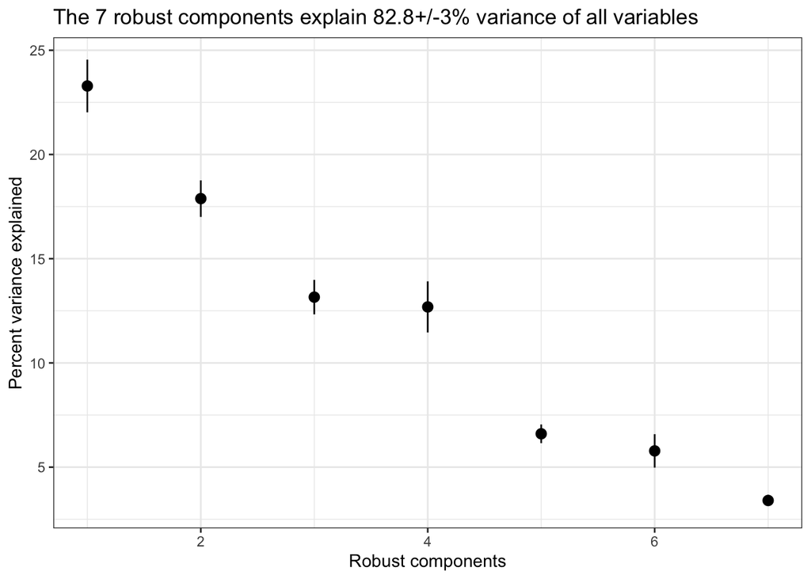

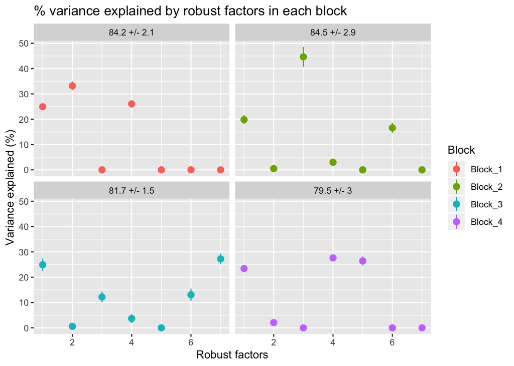

```r
tmp <- paste0(round(ve_full$ve.by.block$Mean, 1), ' +/- ', round(ve_full$ve.by.block$SE, 1))
block.labs <- c("Block_1" = tmp[1], "Block_2" = tmp[2], "Block_3" = tmp[3], "Block_4" = tmp[4])

p <- ggplot(ve_full$ve.by.block.comp,
            aes(x=Component, y=Mean, ymin=Mean-SE, ymax=Mean+SE, color=Block)) +
  geom_pointrange() +
  facet_wrap(~ Block, labeller = labeller(Block = block.labs)) +
  xlab('Robust factors') + ylab('Variance explained (%)') +
  ggtitle("% variance explained by robust factors in each block")
p
```

```r
rWX_full <- rob_wx(models=gfaList_p50, indices=ve_full$indices, block.labs=block4vars, var.labs=paste0("V", 1:40))
save(rWX_full, file=paste0(mydir, "res/", folder, "/rWX_full.rda"))
```

```r
load(paste0(mydir, "res/", folder, "/rWX_full.rda"))
gfa_heatmap(robW=rWX_full, block.names=block.names, varIdx.by.block=varIdx.by.block, conf.level=0.95, heatmap.rep=FALSE, factor.order=NULL)
# ggarrange(w_heatmap.true, w_heatmap.full, nrow=1, ncol=2)
```

Similarity (correlations) between true factor loadings (rows) and estimated (columns)

```r
load(paste0(mydir, "res/", folder, "/rWX_full.rda"))
# dim(rWX_full$w.med)
sim_true_full <- matrix(NA, ncol(W), ncol(rWX_full$w.med),
                        dimnames=list(True=paste0("K", 1:ncol(W)), Matched=paste0("K", 1:ncol(rWX_full$w.med))))
for (i in 1:ncol(W)){
  for(j in 1:ncol(rWX_full$w.med)){
    sim_true_full[i,j] <- cor(W[,i], rWX_full$w.med[,j])
  }
}
```

```r
heatmap.2(sim_true_full, col=c('cyan','deepskyblue3',"blue",'black','brown','orange',"yellow"),
          dendrogram='none', scale="none",
          cexRow = 0.8, cexCol=0.8, Colv=F, Rowv=F, density.info="none", trace="none",
          srtCol=0,   adjCol = c(0.5,1), symkey = F,
          breaks = c(-1.0, -0.8, -0.5, -0.2, 0.2, 0.5, 0.8, 1.0),
          main="Corr. in W b/w true and estimated (K=7)" )
```

Factor 3 was matched twice (Matched factor K6 was correlated with true K3 and K5 with r=0.52 and 0.47)

```r
round(abs(sim_true_full), 2)
```

```
##     Matched
## True   K1   K2   K3   K4   K5   K6   K7
##   K1 0.92 0.17 0.19 0.03 0.01 0.00 0.34
##   K2 0.07 0.08 0.03 0.96 0.16 0.01 0.02
##   K3 0.02 0.01 0.89 0.03 0.04 0.52 0.04
##   K4 0.07 0.97 0.02 0.00 0.03 0.01 0.01
##   K5 0.01 0.01 0.80 0.02 0.04 0.47 0.02
##   K6 0.28 0.01 0.06 0.02 0.04 0.05 1.00
##   K7 0.01 0.02 0.04 0.06 0.96 0.01 0.02
```

```r
table(apply(abs(sim_true_full), 2, which.max))
```

```
##
## 1 2 3 4 6 7
## 1 1 2 1 1 1
```

```r
# data.frame(Ture = paste0("K", 1:7), Matched = paste0("K", apply(abs(sim_true_full), 1, which.max)), corr = round(apply(abs(sim_true_full), 1, max), 2) )
```

### 1.4.2 Robust factors identified using a list of posterior mean of reconstructed data and min-MSE criterion

These two approaches led to the identical matching indices

```r
all.equal(match_orig$indices[[1]][[4]], match.mse$indices[[1]][[4]])
```

```
## [1] TRUE
```

### 1.4.2 Robust factors identified using a list of posterior mean of reconstructed data and 1-SE criterion

The matching indices were identical to the previous two approaches

```r
all.equal(match.mse$indices[[1]], match.mse$indices[[2]])
all.equal(match.mse$indices[[1]], match.mse$indices[[3]])
all.equal(abs(match.mse$indices[[1]][[1]]), abs(match.mse$indices[[3]][[1]]))
all.equal(match.mse$indices[[3]][[1]], match.mse$indices[[3]][[2]])
all.equal(match.mse$indices[[3]][[1]], match.mse$indices[[3]][[3]])
all.equal(match.mse$indices[[3]][[1]], match.mse$indices[[3]][[4]])
all.equal(match.mse$indices[[3]][[1]], match.mse$indices[[3]][[5]])
all.equal(match.mse$indices[[3]][[1]], match.mse$indices[[3]][[6]])

for (r in 1:R){
  tmp <- all.equal(abs(match.mse$indices[[1]][[1]][r,]), abs(match.mse$indices[[3]][[1]][r,]))
  if(tmp!=TRUE){
    print(paste0("Indices differed in Replicate ", r))
  }
}
```

```r
match.mse$indices[[1]][[1]][7,]
match.mse$indices[[3]][[1]][7,]

load(paste0(mydir, "res/", folder, "/gfaList_p50.rda.rda"))
rob.ind <- list(indices=match.mse$indices[[1]][[4]])
ve_full <- rob.var.exp(models=gfaList_p50, indices=rob.ind, block.names=block.names, varIdx.by.block=varIdx.by.block, use.unmatched=T, by.block=T)
```

# 2. (N,D,K,sd.noise) = (100, 40, 7, 1)

## 2.1. Simulate data

X and Y

```r
folder <- "N100_D40_K7_noise1"
set.seed(123)
dat <- data.simu(N=100, W_DxK=W, varIdx.by.block, sd.noise=1)
names(dat$Y.list) <- block.names
mynorm <- normalizeData(train=dat$Y.list, type="scaleFeatures")
Y <- do.call(cbind, mynorm$train)
```

## 2.2 Replicate GFA

```r
foreach(r = 1:11, .packages=c("GFA")) %dopar% {
  set.seed(r)
  res <- gfa(mynorm$train, opts=opts, K=10)
  save(res, file=paste0(mydir, "res/", folder, "/GFA_rep_", r, ".rda"))
}
```

With noise SD = 1, 1/11 replicates did not converge and it returned K=8; all other 10 replicates converged and returned the correct K=7 or K=6:

```r
R <- 11
rep.summ <- data.frame(Replicate=1:R, conv=rep(NA, R), K=rep(NA, R))
gfaList_full <- list()
for(r in 1:R){
  load(paste0(mydir, "res/", folder, "/GFA_rep_", r, ".rda"))
  gfaList_full[[r]] <- res
  rep.summ$conv[r] <- res$conv
  rep.summ$K[r] <- res$K
}
summary(rep.summ$conv)
```

```
##    Min. 1st Qu.  Median    Mean 3rd Qu.    Max.
## 0.03675 0.04512 0.05000 0.05461 0.05663 0.10775
```

```r
table(rep.summ$K)
```

```
##
## 6 7 8
## 5 5 1
```

```r
rep.summ[rep.summ$conv>0.1,]
```

```
##   Replicate    conv K
## 4         4 0.10775 8
```

```r
# rep.summ[rep.summ$conv<0.1,]
gfaList_full <- gfaList_full[-4]
```

## 2.3 Identify robust factors

### 2.3.1 Using a list of original GFA objects

```r
tmp <- matrix(rep(NA, length(corGrids)*length(matchGrids)),
              nrow = length(corGrids), ncol = length(matchGrids),
              dimnames = list(corThr=corGrids, matchThr=matchGrids))

match_orig <- list(K.girds = tmp, mse.m = tmp)

for(i in 1:length(corGrids)){
  for (j in 1:length(matchGrids)){
    rcomp <- robustComponents(gfaList_full, corThr=corGrids[i], matchThr=matchGrids[j])
    save(rcomp, file=paste0(mydir, "res/", folder, "/rComp_corThr", corGrids[i], "_matchThr", matchGrids[j], ".rda"))
    match_orig$K.girds[i,j] <- rcomp$Krobust
    yhat <- apply(rcomp$effect, 1:2, sum, na.rm=T)
    match_orig$mse.m[i,j] <- mean((yhat - Y)^2)
  }
}
save(match_orig, file=paste0(mydir, "res/", folder, "/match_orig.rda"))
```

Despite the 10 replicates returned 6 or 7 factors, the robustComponents() would suggest 8 > 7 (true K) factors:

```r
print("Factor numbers for the 10 converged replicates:")
```

```
## [1] "Factor numbers for the 10 converged replicates:"
```

```r
table(sapply(gfaList_full, `[[`, 11))
```

```
##
## 6 7
## 5 5
```

```r
load(paste0(mydir, "res/", folder, "/match_orig.rda"))
match_orig$K.girds
```

```
##       matchThr
## corThr 0.1 0.3 0.5 0.6 0.7 0.8 0.9
##    0.1   8   7   6   6   6   6   6
##    0.3   8   7   6   6   6   6   6
##    0.5   8   7   6   6   6   6   6
##    0.6   8   7   6   6   6   6   6
##    0.7   8   7   6   6   6   6   6
##    0.8   8   7   6   6   6   6   6
##    0.9   8   7   6   6   6   6   6
```

```r
round(match_orig$mse.m, 3)
```

```
##       matchThr
## corThr   0.1   0.3   0.5   0.6   0.7   0.8   0.9
##    0.1 0.435 0.457 0.482 0.482 0.482 0.482 0.482
##    0.3 0.435 0.457 0.482 0.482 0.482 0.482 0.482
##    0.5 0.435 0.457 0.482 0.482 0.482 0.482 0.482
##    0.6 0.435 0.457 0.482 0.482 0.482 0.482 0.482
##    0.7 0.435 0.457 0.482 0.482 0.482 0.482 0.482
##    0.8 0.435 0.457 0.482 0.482 0.482 0.482 0.482
##    0.9 0.435 0.457 0.482 0.482 0.482 0.482 0.482
```

```r
paste0("The min. MSE = ", round(min(match_orig$mse.m), 3))
```

```
## [1] "The min. MSE = 0.435"
```

```r
tmp <- match_orig$K.girds
tmp[match_orig$mse.m > min(match_orig$mse.m)] <- NA
paste0("GFA::robustComponents() suggested ", median(tmp, na.rm=T), " factors")
```

```
## [1] "GFA::robustComponents() suggested 8 factors"
```

The matching indices for the (corThr, matchThr) = (0.6, 0.1) thresholding parameters revealed some duplicated factors (e.g. "6: in rep2, 3, 5)

```r
load(paste0(mydir, "res/", folder, "/rComp_corThr0.6_matchThr0.1.rda"))
rcomp$indices
```

```
##       K1 K2 K3 K4 K5 K6 K7 K8
## rep1   1  2  3  4  5  6  7  0
## rep2   3  2  4  5  7 -6  1  6
## rep3   2  3  1  4  5 -6  6  0
## rep4   1  3  4  7  6 -5  2  5
## rep5   1  3  2  4  5 -6  6  0
## rep6   1  2  4  5  6 -3  3  0
## rep7   1  3  2  5  6 -4  4  0
## rep8   1  4  2  7  5 -6  3  6
## rep9   4  1  2  5  6 -3  3  0
## rep10  1  2  4  7  6 -5  3  5
```

### 2.3.2. Using a list of posterior means of reconstructed data

```r
R <- 11
rep.summ <- data.frame(Replicate=1:R, conv=rep(NA, R), K=rep(NA, R))
xw <- list()
for(r in 1:R){
  load(paste0(mydir, "res/", folder, "/GFA_rep_", r, ".rda"))
  xw[[r]] <- pmXW_by_factor(res)
  rep.summ$conv[r] <- res$conv
  rep.summ$K[r] <- res$K
}
rep.summ[rep.summ$conv>0.1,]
xw <- xw[-4]
save(xw, file=paste0(mydir, "res/", folder, "/xw_by_rep_comp.rda"))
```

```r
load(paste0(mydir, "res/", folder, "/xw_by_rep_comp.rda"))
system.time(
  match.mse <- MSE.Grids(
    Ymtx=Y,                       ## the observed (normalized) data matrix (N x D)
    maxK = max(rep.summ$K),       ## the maximal K among the GFA replicates
    comps=xw,                     ## a list of GFA replicates with posterior medians
    corGrids=corGrids,            ## the grids of corThr values to be assessed
    matchGrids=matchGrids)        ## the grids of matchThr values to be assessed
)
save(match.mse, file=paste0(mydir, "res/", folder, "/MSE_xwList.rda"))
```

Numbers of matched factors for each (corThr, matchThr) combination:

```r
load(paste0(mydir, "res/", folder, "/MSE_xwList.rda"))
match.mse$K.grid
```

```
##       matchThr
## corThr 0.1 0.3 0.5 0.6 0.7 0.8 0.9
##    0.1   7   7   6   6   6   6   6
##    0.3   7   7   6   6   6   6   6
##    0.5   7   7   6   6   6   6   6
##    0.6   7   7   6   6   6   6   6
##    0.7   7   7   6   6   6   6   6
##    0.8   7   7   6   6   6   6   6
##    0.9   7   7   6   6   6   6   6
```

Both criteria suggested the correct K=7:

```r
opt.par <- optimizeK(K.grids=match.mse$K.grid, mse.array=match.mse$mse$all)
round(opt.par$mse.m, 3)
```

```
##       matchThr
## corThr   0.1   0.3   0.5   0.6   0.7   0.8   0.9
##    0.1 0.471 0.471 0.483 0.483 0.483 0.483 0.483
##    0.3 0.471 0.471 0.483 0.483 0.483 0.483 0.483
##    0.5 0.471 0.471 0.483 0.483 0.483 0.483 0.483
##    0.6 0.471 0.471 0.483 0.483 0.483 0.483 0.483
##    0.7 0.471 0.471 0.483 0.483 0.483 0.483 0.483
##    0.8 0.471 0.471 0.483 0.483 0.483 0.483 0.483
##    0.9 0.471 0.471 0.483 0.483 0.483 0.483 0.483
```

```r
paste0("The min. MSE = ", round(opt.par$mse.min, 3))
```

```
## [1] "The min. MSE = 0.471"
```

```r
paste0("The 1-SE MSE threshold = ", round(opt.par$mseThr, 3))
```

```
## [1] "The 1-SE MSE threshold = 0.483"
```

```r
paste0("min. MSE criterion gives ", opt.par$Krobust.min, " matched factors")
```

```
## [1] "min. MSE criterion gives 7 matched factors"
```

```r
paste0("1-SE MSE criterion gives ", opt.par$Krobust.1se, " matched factors")
```

```
## [1] "1-SE MSE criterion gives 7 matched factors"
```

# 3. (N,D,K,sd.noise) = (100, 40, 7, 2)

## 3.1. Simulate data

X and Y

```r
folder <- "N100_D40_K7_noise2"
set.seed(123)
dat <- data.simu(N=100, W_DxK=W, varIdx.by.block, sd.noise=2)
names(dat$Y.list) <- block.names
mynorm <- normalizeData(train=dat$Y.list, type="scaleFeatures")
Y <- do.call(cbind, mynorm$train)
```

## 3.2 Replicate GFA

```r
foreach(r = 1:12, .packages=c("GFA")) %dopar% {
  set.seed(r)
  res <- gfa(mynorm$train, opts=opts, K=10)
  save(res, file=paste0(mydir, "res/", folder, "/GFA_rep_", r, ".rda"))
}
```

With noise SD = 2, 2/12 replicates did not converge and they returned K=4 and 3; all other 10 replicates converged but also returned K=3 or 4:

```r
R <- 12
rep.summ <- data.frame(Replicate=1:R, conv=rep(NA, R), K=rep(NA, R))
gfaList_full <- list()
for(r in 1:R){
  load(paste0(mydir, "res/", folder, "/GFA_rep_", r, ".rda"))
  gfaList_full[[r]] <- res
  rep.summ$conv[r] <- res$conv
  rep.summ$K[r] <- res$K
}
summary(rep.summ$conv)
```

```
##    Min. 1st Qu.  Median    Mean 3rd Qu.    Max.
## 0.04300 0.05081 0.05312 0.06410 0.05556 0.12825
```

```r
table(rep.summ$K)
```

```
##
## 3 4
## 9 3
```

```r
rep.summ[rep.summ$conv>0.08,]
```

```
##   Replicate    conv K
## 6         6 0.12825 4
## 7         7 0.12375 3
```

```r
gfaList_full <- gfaList_full[-c(6,7)]
table(sapply(gfaList_full, `[[`, 11))
```

```
##
## 3 4
## 8 2
```

# 4. (N,D,K,sd.noise) = (100, 43, 18, 0)

## 4.1. Simulate data

W matrix:

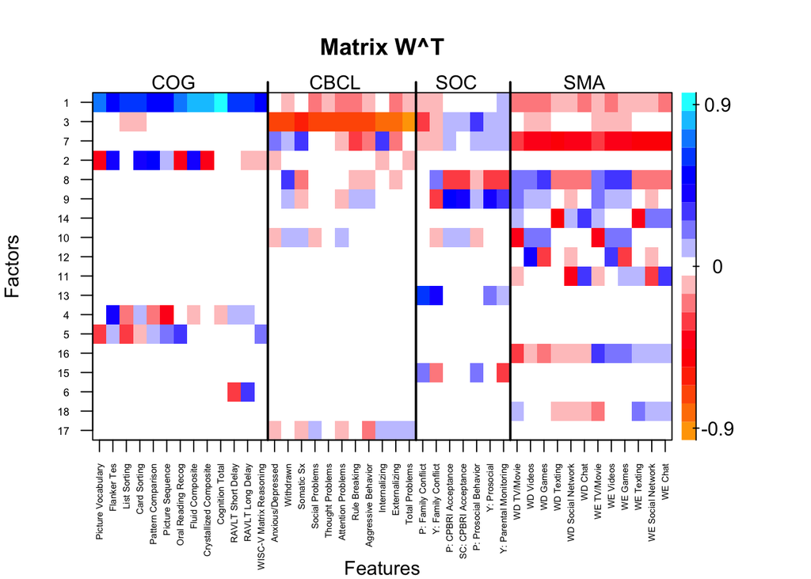

```r
folder <- "N100_D43_K18_noise0"
load("/Users/hyeh/Dropbox (LIBR)/Henry_Yeh/ABCD/COG_CBCL_SOC_SMA/res/rWX_p50.rda")
W <- rWX_p50$w.med
block.names <- c("COG", "CBCL", "SOC", "SMA")
varIdx.by.block <- list(c(1:13), 13+c(1:11), 13+11+c(1:7), 13+11+7+c(1:12))
ve <- diag(var(W))
W <- W[,order(-ve)]
W_heatmap(W_DxK=W, varIdx.by.block, block.names)
```

X and Y

```r
set.seed(123)
dat <- data.simu(N=100, W_DxK=W, varIdx.by.block, sd.noise=0)
names(dat$Y.list) <- block.names
mynorm <- normalizeData(train=dat$Y.list, type="scaleFeatures")
Y <- do.call(cbind, mynorm$train)
```

## 4.2 Replicate GFA

```r
foreach(r = 1:15, .packages=c("GFA")) %dopar% {
  set.seed(r)
  res <- gfa(mynorm$train, opts=opts, K=25)
  save(res, file=paste0(mydir, "res/", folder, "/GFA_rep_", r, ".rda"))
}
```

With no noise, all 15 replicates converged and most returned the correct K=18:

```r
R <- 15
rep.summ <- data.frame(Replicate=1:R, conv=rep(NA, R), K=rep(NA, R))
gfaList_full <- list()
for(r in 1:R){
  load(paste0(mydir, "res/", folder, "/GFA_rep_", r, ".rda"))
  gfaList_full[[r]] <- res
  rep.summ$conv[r] <- res$conv
  rep.summ$K[r] <- res$K
}
summary(rep.summ$conv)
```

```
##    Min. 1st Qu.  Median    Mean 3rd Qu.    Max.
## 0.04698 0.05140 0.05465 0.05594 0.06093 0.06767
```

```r
table(rep.summ$K)
```

```
##
## 17 18
##  3 12
```

Take the 10 replicates with lowest convergence stats

```r
rep.use <- sort(rep.summ$conv, index.return=T)
# round(rep.summ$conv[rep.use$ix[1:10]], 3)
table(rep.summ$K[rep.use$ix[1:10]])
```

```
##
## 17 18
##  3  7
```

```r
gfaList_full <- gfaList_full[rep.use$ix[1:10]]
```

## 4.3 Identify robust factors

### 4.3.1 Using a list of the original GFA objects

```r
tmp <- matrix(rep(NA, length(corGrids)*length(matchGrids)),
              nrow = length(corGrids), ncol = length(matchGrids),
              dimnames = list(corThr=corGrids, matchThr=matchGrids))

match_orig <- list(K.girds = tmp, mse.m = tmp)

for(i in 1:length(corGrids)){
  for (j in 1:length(matchGrids)){
    rcomp <- robustComponents(gfaList_full, corThr=corGrids[i], matchThr=matchGrids[j])
    save(rcomp, file=paste0(mydir, "res/", folder, "/rComp_corThr", corGrids[i], "_matchThr", matchGrids[j], ".rda"))
    # load(paste0(mydir, "res/", folder, "rComp_corThr", corGrids[i], "_matchThr", matchGrids[j], ".rda"))
    match_orig$K.girds[i,j] <- rcomp$Krobust
    yhat <- apply(rcomp$effect, 1:2, sum, na.rm=T)
    match_orig$mse.m[i,j] <- mean((yhat - Y)^2)
  }
}
save(match_orig, file=paste0(mydir, "res/", folder, "/match_orig.rda"))
```

The robustComponents() would suggest correct K=18 factors:

```r
load(paste0(mydir, "res/", folder, "/match_orig.rda"))

match_orig$K.girds
```

```
##       matchThr
## corThr 0.1 0.3 0.5 0.6 0.7 0.8 0.9
##    0.1  18  18  18  18  18  18  17
##    0.3  19  18  18  18  18  18  17
##    0.5  21  18  18  18  18  18  17
##    0.6  23  19  19  18  18  18  16
##    0.7  30  21  19  19  18  18  15
##    0.8  39  20  17  16  15  15  12
##    0.9  63  15  14  14  14  11   8
```

```r
round(match_orig$mse.m, 3)
```

```
##       matchThr
## corThr   0.1   0.3   0.5   0.6   0.7   0.8   0.9
##    0.1 0.002 0.002 0.002 0.002 0.002 0.002 0.008
##    0.3 0.044 0.002 0.002 0.002 0.002 0.002 0.008
##    0.5 0.066 0.003 0.003 0.003 0.003 0.003 0.008
##    0.6 0.141 0.006 0.006 0.004 0.003 0.003 0.028
##    0.7 0.447 0.050 0.010 0.007 0.003 0.002 0.041
##    0.8 1.033 0.028 0.024 0.035 0.060 0.058 0.130
##    0.9 5.234 0.059 0.097 0.097 0.097 0.180 0.325
```

```r
paste0("The min. MSE = ", round(min(match_orig$mse.m), 3))
```

```
## [1] "The min. MSE = 0.002"
```

```r
tmp <- match_orig$K.girds
tmp[match_orig$mse.m > min(match_orig$mse.m)] <- NA
tmp[1:2,]
```

```
##       matchThr
## corThr 0.1 0.3 0.5 0.6 0.7 0.8 0.9
##    0.1  18  18  18  18  18  18  NA
##    0.3  NA  NA  NA  NA  NA  NA  NA
```

### 4.3.2. Using a list of posterior mean of reconstructed data

```r
R <- 15
rep.summ <- data.frame(Replicate=1:R, conv=rep(NA, R), K=rep(NA, R))
xw <- list()
for(r in 1:R){
  load(paste0(mydir, "res/", folder, "/GFA_rep_", r, ".rda"))
  xw[[r]] <- pmXW_by_factor(res)
  rep.summ$conv[r] <- res$conv
  rep.summ$K[r] <- res$K
}
rep.use <- sort(rep.summ$conv, index.return=T)
rep.use$ix[1:10]
xw <- xw[rep.use$ix[1:10]]
save(xw, file=paste0(mydir, "res/", folder, "/xw_by_rep_comp.rda"))
```

```r
load(paste0(mydir, "res/", folder, "/xw_by_rep_comp.rda"))
system.time(
  match.mse <- MSE.Grids(
    Ymtx=Y,                       ## the observed (normalized) data matrix (N x D)
    maxK = max(rep.summ$K),       ## the maximal K among the GFA replicates
    comps=xw,                     ## a list of GFA replicates with posterior medians
    corGrids=corGrids,            ## the grids of corThr values to be assessed
    matchGrids=matchGrids)        ## the grids of matchThr values to be assessed
)
save(match.mse, file=paste0(mydir, "res/", folder, "/MSE_xwList.rda"))
```

Numbers of matched factors for each (corThr, matchThr) combination:

```r
load(paste0(mydir, "res/", folder, "/MSE_xwList.rda"))
match.mse$K.grid
```

```
##       matchThr
## corThr 0.1 0.3 0.5 0.6 0.7 0.8 0.9
##    0.1  18  18  18  18  18  17  16
##    0.3  18  18  18  18  18  17  16
##    0.5  19  18  18  18  18  17  14
##    0.6  20  19  18  18  18  16  14
##    0.7  22  21  19  18  18  15  11
##    0.8  25  20  16  15  15  12   8
##    0.9  29  15  14  14  11   8   5
```

Both criteria suggested the correct K=18:

```r
opt.par <- optimizeK(K.grids=match.mse$K.grid, mse.array=match.mse$mse$all)
round(opt.par$mse.m, 3)
```

```
##       matchThr
## corThr   0.1   0.3   0.5   0.6   0.7   0.8   0.9
##    0.1 0.004 0.004 0.004 0.004 0.004 0.008 0.013
##    0.3 0.004 0.004 0.004 0.004 0.004 0.008 0.013
##    0.5 0.013 0.006 0.006 0.006 0.005 0.009 0.056
##    0.6 0.047 0.025 0.020 0.013 0.013 0.035 0.058
##    0.7 0.147 0.100 0.036 0.021 0.017 0.051 0.150
##    0.8 0.314 0.051 0.048 0.070 0.071 0.135 0.316
##    0.9 0.676 0.077 0.112 0.112 0.193 0.337 0.402
```

```r
paste0("The min. MSE = ", round(opt.par$mse.min, 3))
```

```
## [1] "The min. MSE = 0.004"
```

```r
paste0("The 1-SE MSE threshold = ", round(opt.par$mseThr, 3))
```

```
## [1] "The 1-SE MSE threshold = 0.008"
```

```r
paste0("min. MSE criterion gives ", opt.par$Krobust.min, " matched factors")
```

```
## [1] "min. MSE criterion gives 18 matched factors"
```

```r
paste0("1-SE MSE criterion gives ", opt.par$Krobust.1se, " matched factors")
```

```
## [1] "1-SE MSE criterion gives 18 matched factors"
```

# 5. (N,D,K,sd.noise) = (100, 43, 18, 0.2)

## 5.1. Simulate data

X and Y

```r
folder <- "N100_D43_K18_noise0.2"
set.seed(123)
dat <- data.simu(N=100, W_DxK=W, varIdx.by.block, sd.noise=0.2)
names(dat$Y.list) <- block.names
mynorm <- normalizeData(train=dat$Y.list, type="scaleFeatures")
Y <- do.call(cbind, mynorm$train)
```

## 5.2 Replicate GFA

```r
foreach(r = 1:15, .packages=c("GFA")) %dopar% {
  set.seed(r)
  res <- gfa(mynorm$train, opts=opts, K=25)
  save(res, file=paste0(mydir, "res/", folder, "/GFA_rep_", r, ".rda"))
}
```

```r
R <- 15
rep.summ <- data.frame(Replicate=1:R, conv=rep(NA, R), K=rep(NA, R))
gfaList_full <- list()
for(r in 1:R){
  load(paste0(mydir, "res/", folder, "/GFA_rep_", r, ".rda"))
  gfaList_full[[r]] <- res
  rep.summ$conv[r] <- res$conv
  rep.summ$K[r] <- res$K
}
summary(rep.summ$conv)
```

```
##    Min. 1st Qu.  Median    Mean 3rd Qu.    Max.
## 0.04233 0.04744 0.05047 0.05186 0.05558 0.07442
```

```r
table(rep.summ$K)
```

```
##
## 16 17 18
##  7  6  2
```

Take the 10 replicates with lowest convergence stats

```r
rep.use <- sort(rep.summ$conv, index.return=T)
# round(rep.summ$conv[rep.use$ix[1:10]], 3)
table(rep.summ$K[rep.use$ix[1:10]])
```

```
##
## 16 17 18
##  6  3  1
```

```r
gfaList_full <- gfaList_full[rep.use$ix[1:10]]
```

## 5.3 Identify robust factors

### 5.3.1 Using a list of the original GFA objects

```r
tmp <- matrix(rep(NA, length(corGrids)*length(matchGrids)),
              nrow = length(corGrids), ncol = length(matchGrids),
              dimnames = list(corThr=corGrids, matchThr=matchGrids))

match_orig <- list(K.girds = tmp, mse.m = tmp)

for(i in 1:length(corGrids)){
  for (j in 1:length(matchGrids)){
    rcomp <- robustComponents(gfaList_full, corThr=corGrids[i], matchThr=matchGrids[j])
    save(rcomp, file=paste0(mydir, "res/", folder, "/rComp_corThr", corGrids[i], "_matchThr", matchGrids[j], ".rda"))
    match_orig$K.girds[i,j] <- rcomp$Krobust
    yhat <- apply(rcomp$effect, 1:2, sum, na.rm=T)
    match_orig$mse.m[i,j] <- mean((yhat - Y)^2)
  }
}
save(match_orig, file=paste0(mydir, "res/", folder, "/match_orig.rda"))
```

The robustComponents() would suggest correct K=18 factors:

```r
load(paste0(mydir, "res/", folder, "/match_orig.rda"))

match_orig$K.girds
```

```
##       matchThr
## corThr 0.1 0.3 0.5 0.6 0.7 0.8 0.9
##    0.1  18  16  16  16  16  16  16
##    0.3  18  16  16  16  16  16  16
##    0.5  18  16  16  16  16  16  16
##    0.6  20  16  16  16  16  16  16
##    0.7  21  16  16  16  16  16  16
##    0.8  30  16  16  16  16  14  14
##    0.9  51  17  14  13  11   9   9
```

```r
round(match_orig$mse.m, 3)
```

```
##       matchThr
## corThr   0.1   0.3   0.5   0.6   0.7   0.8   0.9
##    0.1 0.055 0.067 0.067 0.067 0.067 0.067 0.067
##    0.3 0.055 0.067 0.067 0.067 0.067 0.067 0.067
##    0.5 0.055 0.067 0.067 0.067 0.067 0.067 0.067
##    0.6 0.093 0.067 0.067 0.067 0.067 0.067 0.067
##    0.7 0.092 0.067 0.067 0.067 0.067 0.067 0.067
##    0.8 0.313 0.067 0.067 0.067 0.067 0.090 0.088
##    0.9 1.843 0.071 0.100 0.111 0.154 0.206 0.206
```

```r
paste0("The min. MSE = ", round(min(match_orig$mse.m), 3))
```

```
## [1] "The min. MSE = 0.055"
```

```r
tmp <- match_orig$K.girds
tmp[match_orig$mse.m > min(match_orig$mse.m)] <- NA
tmp
```

```
##       matchThr
## corThr 0.1 0.3 0.5 0.6 0.7 0.8 0.9
##    0.1  18  NA  NA  NA  NA  NA  NA
##    0.3  18  NA  NA  NA  NA  NA  NA
##    0.5  18  NA  NA  NA  NA  NA  NA
##    0.6  NA  NA  NA  NA  NA  NA  NA
##    0.7  NA  NA  NA  NA  NA  NA  NA
##    0.8  NA  NA  NA  NA  NA  NA  NA
##    0.9  NA  NA  NA  NA  NA  NA  NA
```

### 5.3.2. Using a list of posterior mean of reconstructed data

```r
R <- 15
rep.summ <- data.frame(Replicate=1:R, conv=rep(NA, R), K=rep(NA, R))
xw <- list()
for(r in 1:R){
  load(paste0(mydir, "res/", folder, "/GFA_rep_", r, ".rda"))
  xw[[r]] <- pmXW_by_factor(res)
  rep.summ$conv[r] <- res$conv
  rep.summ$K[r] <- res$K
}
rep.use <- sort(rep.summ$conv, index.return=T)
rep.use$ix[1:10]
xw <- xw[rep.use$ix[1:10]]
save(xw, file=paste0(mydir, "res/", folder, "/xw_by_rep_comp.rda"))
```

```r
load(paste0(mydir, "res/", folder, "/xw_by_rep_comp.rda"))
system.time(
  match.mse <- MSE.Grids(
    Ymtx=Y,                       ## the observed (normalized) data matrix (N x D)
    maxK = max(rep.summ$K),       ## the maximal K among the GFA replicates
    comps=xw,                     ## a list of GFA replicates with posterior medians
    corGrids=corGrids,            ## the grids of corThr values to be assessed
    matchGrids=matchGrids)        ## the grids of matchThr values to be assessed
)
save(match.mse, file=paste0(mydir, "res/", folder, "/MSE_xwList.rda"))
```

Numbers of matched factors for each (corThr, matchThr) combination:

```r
load(paste0(mydir, "res/", folder, "/MSE_xwList.rda"))
match.mse$K.grid
```

```
##       matchThr
## corThr 0.1 0.3 0.5 0.6 0.7 0.8 0.9
##    0.1  18  16  16  16  16  16  15
##    0.3  18  16  16  16  16  16  15
##    0.5  18  16  16  16  16  16  15
##    0.6  18  16  16  16  16  16  15
##    0.7  19  16  16  16  16  16  12
##    0.8  20  16  16  16  14  14  10
##    0.9  28  17  13  11   9   9   5
```

Min-MSE and 1-SE criteria suggested the correct K=18 and K=16, respectively:

```r
opt.par <- optimizeK(K.grids=match.mse$K.grid, mse.array=match.mse$mse$all)
round(opt.par$mse.m, 3)
```

```
##       matchThr
## corThr   0.1   0.3   0.5   0.6   0.7   0.8   0.9
##    0.1 0.066 0.069 0.069 0.069 0.069 0.069 0.083
##    0.3 0.066 0.069 0.069 0.069 0.069 0.069 0.083
##    0.5 0.066 0.069 0.069 0.069 0.069 0.069 0.083
##    0.6 0.084 0.069 0.069 0.069 0.069 0.069 0.083
##    0.7 0.108 0.069 0.069 0.069 0.069 0.069 0.156
##    0.8 0.103 0.070 0.070 0.070 0.094 0.093 0.195
##    0.9 0.296 0.075 0.114 0.156 0.208 0.208 0.413
```

```r
paste0("The min. MSE = ", round(opt.par$mse.min, 3))
```

```
## [1] "The min. MSE = 0.066"
```

```r
paste0("The 1-SE MSE threshold = ", round(opt.par$mseThr, 3))
```

```
## [1] "The 1-SE MSE threshold = 0.073"
```

```r
paste0("min. MSE criterion gives ", opt.par$Krobust.min, " matched factors")
```

```
## [1] "min. MSE criterion gives 18 matched factors"
```

```r
paste0("1-SE MSE criterion gives ", opt.par$Krobust.1se, " matched factors")
```

```
## [1] "1-SE MSE criterion gives 16 matched factors"
```

# 6. (N,D,K,sd.noise) = (100, 43, 37, 0)

## 6.1. Simulate data

W matrix:

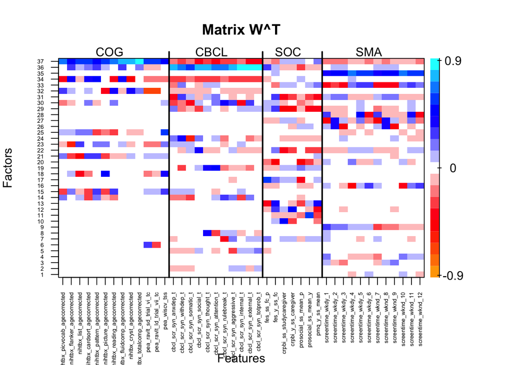

```r
folder <- "N100_D43_K37_noise0"
load("/Users/hyeh/Dropbox (LIBR)/RData/nda18_2.01_COG_CBCL_SOC_SMA4_10.31.2019.RData")
W <- apply(myres$posterior$W, 2:3, mean)
rm(myres)
block.names <- c("COG", "CBCL", "SOC", "SMA")
varIdx.by.block <- list(c(1:13), 13+c(1:11), 13+11+c(1:7), 13+11+7+c(1:12))
ve <- diag(var(W))
W <- W[,order(-ve)]
W_heatmap(W_DxK=W, varIdx.by.block, block.names)
```

X and Y

```r
set.seed(123)
dat <- data.simu(N=100, W_DxK=W, varIdx.by.block, sd.noise=0)
names(dat$Y.list) <- block.names
mynorm <- normalizeData(train=dat$Y.list, type="scaleFeatures")
Y <- do.call(cbind, mynorm$train)
```

## 6.2 Replicate GFA

Set initial K=42 (default is D/2 and will give no more than D=43/2 ~ 22 factors)

```r
foreach(r = 1:15, .packages=c("GFA")) %dopar% {
  set.seed(r)
  res <- gfa(mynorm$train, opts=opts, K=42)
  save(res, file=paste0(mydir, "res/", folder, "/GFA_rep_", r, ".rda"))
}
```

Even without noise, 15 replicates returned K from 17 to 20, far from the true K=37.

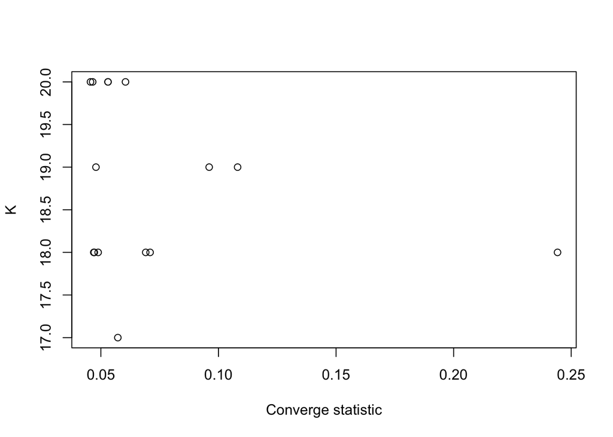

```r
R <- 15
rep.summ <- data.frame(Replicate=1:R, conv=rep(NA, R), K=rep(NA, R))
gfaList_full <- list()
for(r in 1:R){
  load(paste0(mydir, "res/", folder, "/GFA_rep_", r, ".rda"))
  gfaList_full[[r]] <- res
  rep.summ$conv[r] <- res$conv
  rep.summ$K[r] <- res$K
}
plot(rep.summ$conv, rep.summ$K, xlab="Converge statistic", ylab="K")
```

```r
rep.summ[rep.summ$conv>0.08,]
```

```
##    Replicate       conv  K
## 6          6 0.24418605 18
## 8          8 0.10813953 19
## 13        13 0.09604651 19
```

```r
summary(rep.summ$conv)
```

```
##    Min. 1st Qu.  Median    Mean 3rd Qu.    Max.
## 0.04558 0.04756 0.05302 0.07301 0.07000 0.24419
```

```r
table(rep.summ$K)
```

```
##
## 17 18 19 20
##  1  6  3  5
```

Take the 10 replicates with lowest convergence stats

```r
rep.use <- sort(rep.summ$conv, index.return=T)
# round(rep.summ$conv[rep.use$ix[1:10]], 3)
table(rep.summ$K[rep.use$ix[1:10]])
```

```
##
## 17 18 19 20
##  1  3  1  5
```

```r
gfaList_full <- gfaList_full[rep.use$ix[1:10]]
```